# 20171213_week+5+Assignment

#### Q1. Please provide a class in Python 3 that will include 3 different functions for rectangular prisms. The first function will calculate the surface area of a rectangular prism, the second one will calculate the volume of this prism, and the third one should properly print these two calculated values on the console.

```python
class RectengularPrism():
    def __init__(self, l, h, w):
        self.length = l
        self.height = h
        self.width = w
    def area(self):
        return  (2 * self.length * self.height) + (2 * self.length * self.width) + (2 * self.width * self.height)
    def volume(self):
        return (self.length * self.height * self.width)

    def PrintCalculated(self):
        print("Area = {0}".format(RectengularPrism.area(self)))
        print("Volume = {0}".format(RectengularPrism.volume(self)))


NewRectengularPrism = RectengularPrism(8,4,2)
NewRectengularPrism.PrintCalculated()
```

```
Area = 112
Volume = 64
```

#### Q2. You are expected to understand the following class and provide the necessary comments to the given places (annotated with “# ….”).

```python
class ComplexNumber:
    def __init__(self,r = 0,i = 0): # ……………………………..
        self.real = r # take r and assign self.real..
        self.imag = i # take i and assign self.imag..
    def getData(self): # take data from __in__ to print(funtion).
        print("{0}+{1}i".format(self.real,self.imag)) # print function

c1 = ComplexNumber(2,3) # Assign Complex Number class 2 as real and 3 as imaginary
# no output
c1.getData() # print 2+3i
c2 = ComplexNumber(5) # Complex Number class 5 as real and no imaginary so defaılt i = 0
# Output no output but if invite getData : 5+0i
c2.attbr = 10 # no comment
c2.getData()
```

```
2+3i
5+0i
```

#### Q3. Please make use of the following Customer class with providing Sarah and Hakeem two different accounts and a series of deposits. Please try to cover all the functions and attributes.

```python
class Customer(object):
    """A customer of ABC Bank with a checking account. Customers have the
    following properties:
    Attributes:
    name: A string representing the customer's name.
    balance: A float tracking the current balance of the customer's account.
    """
    def __init__(self, name, balance=0.0):
        """Return a Customer object whose name is *name* and starting
        balance is *balance*."""
        self.name = name
        self.balance = balance
    def withdraw(self, amount):
        """Return the balance remaining after withdrawing *amount*
        dollars."""
        if amount > self.balance:
            raise RuntimeError('Amount greater than available balance.')
            self.balance -= amount
        return self.balance
    def deposit(self, amount):
        """Return the balance remaining after depositing *amount*
        dollars."""
        self.balance += amount
        return self.balanc
```

```python
c1 = Customer("Ahmet Yetkin",500,400)
c1.deposit()
```

```
---------------------------------------------------------------------------
TypeError                                 Traceback (most recent call last)
<ipython-input-5-24e88f546dd9> in <module>()
----> 1 c1 = Customer("Ahmet Yetkin",500,400)
      2 c1.deposit()

TypeError: __init__() takes from 2 to 3 positional arguments but 4 were given
```

#### Q4. You are expected to provide the descriptive statistics for the Boston dataset. You can make use of the following piece of codes to have a gentle start for this question:

```python
import pandas as pd
from sklearn import datasets
boston = pd.DataFrame(datasets.load_boston().data)
```

```python
boston.shape
```

```
(506, 13)
```

```python
boston.info()
```

```
<class 'pandas.core.frame.DataFrame'>
RangeIndex: 506 entries, 0 to 505
Data columns (total 13 columns):
0     506 non-null float64
1     506 non-null float64
2     506 non-null float64
3     506 non-null float64
4     506 non-null float64
5     506 non-null float64
6     506 non-null float64
7     506 non-null float64
8     506 non-null float64
9     506 non-null float64
10    506 non-null float64
11    506 non-null float64
12    506 non-null float64
dtypes: float64(13)
memory usage: 51.5 KB
```

```python
import pandas as pd
boston.columns = ['A','B','C','D','E','F','G','H','I','J','K','L','M']
```

```python
boston.head()
```

|  | A | B | C | D | E | F | G | H | I | J | K | L | M |
| --- | --- | --- | --- | --- | --- | --- | --- | --- | --- | --- | --- | --- | --- |
| 0 | 0.00632 | 18.0 | 2.31 | 0.0 | 0.538 | 6.575 | 65.2 | 4.0900 | 1.0 | 296.0 | 15.3 | 396.90 | 4.98 |
| 1 | 0.02731 | 0.0 | 7.07 | 0.0 | 0.469 | 6.421 | 78.9 | 4.9671 | 2.0 | 242.0 | 17.8 | 396.90 | 9.14 |
| 2 | 0.02729 | 0.0 | 7.07 | 0.0 | 0.469 | 7.185 | 61.1 | 4.9671 | 2.0 | 242.0 | 17.8 | 392.83 | 4.03 |
| 3 | 0.03237 | 0.0 | 2.18 | 0.0 | 0.458 | 6.998 | 45.8 | 6.0622 | 3.0 | 222.0 | 18.7 | 394.63 | 2.94 |
| 4 | 0.06905 | 0.0 | 2.18 | 0.0 | 0.458 | 7.147 | 54.2 | 6.0622 | 3.0 | 222.0 | 18.7 | 396.90 | 5.33 |

```python
boston.describe()
```

|  | A | B | C | D | E | F | G | H | I | J | K | L | M |
| --- | --- | --- | --- | --- | --- | --- | --- | --- | --- | --- | --- | --- | --- |
| count | 506.000000 | 506.000000 | 506.000000 | 506.000000 | 506.000000 | 506.000000 | 506.000000 | 506.000000 | 506.000000 | 506.000000 | 506.000000 | 506.000000 | 506.000000 |
| mean | 3.593761 | 11.363636 | 11.136779 | 0.069170 | 0.554695 | 6.284634 | 68.574901 | 3.795043 | 9.549407 | 408.237154 | 18.455534 | 356.674032 | 12.653063 |
| std | 8.596783 | 23.322453 | 6.860353 | 0.253994 | 0.115878 | 0.702617 | 28.148861 | 2.105710 | 8.707259 | 168.537116 | 2.164946 | 91.294864 | 7.141062 |
| min | 0.006320 | 0.000000 | 0.460000 | 0.000000 | 0.385000 | 3.561000 | 2.900000 | 1.129600 | 1.000000 | 187.000000 | 12.600000 | 0.320000 | 1.730000 |
| 25% | 0.082045 | 0.000000 | 5.190000 | 0.000000 | 0.449000 | 5.885500 | 45.025000 | 2.100175 | 4.000000 | 279.000000 | 17.400000 | 375.377500 | 6.950000 |
| 50% | 0.256510 | 0.000000 | 9.690000 | 0.000000 | 0.538000 | 6.208500 | 77.500000 | 3.207450 | 5.000000 | 330.000000 | 19.050000 | 391.440000 | 11.360000 |
| 75% | 3.647423 | 12.500000 | 18.100000 | 0.000000 | 0.624000 | 6.623500 | 94.075000 | 5.188425 | 24.000000 | 666.000000 | 20.200000 | 396.225000 | 16.955000 |
| max | 88.976200 | 100.000000 | 27.740000 | 1.000000 | 0.871000 | 8.780000 | 100.000000 | 12.126500 | 24.000000 | 711.000000 | 22.000000 | 396.900000 | 37.970000 |

```python
# correlation matrix
boston.corr()
```

|  | A | B | C | D | E | F | G | H | I | J | K | L | M |
| --- | --- | --- | --- | --- | --- | --- | --- | --- | --- | --- | --- | --- | --- |
| A | 1.000000 | -0.199458 | 0.404471 | -0.055295 | 0.417521 | -0.219940 | 0.350784 | -0.377904 | 0.622029 | 0.579564 | 0.288250 | -0.377365 | 0.452220 |
| B | -0.199458 | 1.000000 | -0.533828 | -0.042697 | -0.516604 | 0.311991 | -0.569537 | 0.664408 | -0.311948 | -0.314563 | -0.391679 | 0.175520 | -0.412995 |
| C | 0.404471 | -0.533828 | 1.000000 | 0.062938 | 0.763651 | -0.391676 | 0.644779 | -0.708027 | 0.595129 | 0.720760 | 0.383248 | -0.356977 | 0.603800 |
| D | -0.055295 | -0.042697 | 0.062938 | 1.000000 | 0.091203 | 0.091251 | 0.086518 | -0.099176 | -0.007368 | -0.035587 | -0.121515 | 0.048788 | -0.053929 |
| E | 0.417521 | -0.516604 | 0.763651 | 0.091203 | 1.000000 | -0.302188 | 0.731470 | -0.769230 | 0.611441 | 0.668023 | 0.188933 | -0.380051 | 0.590879 |
| F | -0.219940 | 0.311991 | -0.391676 | 0.091251 | -0.302188 | 1.000000 | -0.240265 | 0.205246 | -0.209847 | -0.292048 | -0.355501 | 0.128069 | -0.613808 |
| G | 0.350784 | -0.569537 | 0.644779 | 0.086518 | 0.731470 | -0.240265 | 1.000000 | -0.747881 | 0.456022 | 0.506456 | 0.261515 | -0.273534 | 0.602339 |
| H | -0.377904 | 0.664408 | -0.708027 | -0.099176 | -0.769230 | 0.205246 | -0.747881 | 1.000000 | -0.494588 | -0.534432 | -0.232471 | 0.291512 | -0.496996 |
| I | 0.622029 | -0.311948 | 0.595129 | -0.007368 | 0.611441 | -0.209847 | 0.456022 | -0.494588 | 1.000000 | 0.910228 | 0.464741 | -0.444413 | 0.488676 |
| J | 0.579564 | -0.314563 | 0.720760 | -0.035587 | 0.668023 | -0.292048 | 0.506456 | -0.534432 | 0.910228 | 1.000000 | 0.460853 | -0.441808 | 0.543993 |
| K | 0.288250 | -0.391679 | 0.383248 | -0.121515 | 0.188933 | -0.355501 | 0.261515 | -0.232471 | 0.464741 | 0.460853 | 1.000000 | -0.177383 | 0.374044 |
| L | -0.377365 | 0.175520 | -0.356977 | 0.048788 | -0.380051 | 0.128069 | -0.273534 | 0.291512 | -0.444413 | -0.441808 | -0.177383 | 1.000000 | -0.366087 |
| M | 0.452220 | -0.412995 | 0.603800 | -0.053929 | 0.590879 | -0.613808 | 0.602339 | -0.496996 | 0.488676 | 0.543993 | 0.374044 | -0.366087 | 1.000000 |

```python
# covariance matrix
boston.cov()
```

|  | A | B | C | D | E | F | G | H | I | J | K | L | M |
| --- | --- | --- | --- | --- | --- | --- | --- | --- | --- | --- | --- | --- | --- |
| A | 73.904671 | -39.990934 | 23.854453 | -0.120739 | 0.415924 | -1.328491 | 84.886013 | -6.840937 | 46.561611 | 839.717323 | 5.364787 | -296.171637 | 27.761872 |
| B | -39.990934 | 543.936814 | -85.412648 | -0.252925 | -1.396148 | 5.112513 | -373.901548 | 32.629304 | -63.348695 | -1236.453735 | -19.776571 | 373.721402 | -68.783037 |
| C | 23.854453 | -85.412648 | 47.064442 | 0.109669 | 0.607074 | -1.887957 | 124.513903 | -10.228097 | 35.549971 | 833.360290 | 5.692104 | -223.579756 | 29.580270 |
| D | -0.120739 | -0.252925 | 0.109669 | 0.064513 | 0.002684 | 0.016285 | 0.618571 | -0.053043 | -0.016296 | -1.523367 | -0.066819 | 1.131325 | -0.097816 |
| E | 0.415924 | -1.396148 | 0.607074 | 0.002684 | 0.013428 | -0.024603 | 2.385927 | -0.187696 | 0.616929 | 13.046286 | 0.047397 | -4.020570 | 0.488946 |
| F | -1.328491 | 5.112513 | -1.887957 | 0.016285 | -0.024603 | 0.493671 | -4.751929 | 0.303663 | -1.283815 | -34.583448 | -0.540763 | 8.215006 | -3.079741 |
| G | 84.886013 | -373.901548 | 124.513903 | 0.618571 | 2.385927 | -4.751929 | 792.358399 | -44.329379 | 111.770846 | 2402.690122 | 15.936921 | -702.940328 | 121.077725 |
| H | -6.840937 | 32.629304 | -10.228097 | -0.053043 | -0.187696 | 0.303663 | -44.329379 | 4.434015 | -9.068252 | -189.664592 | -1.059775 | 56.040356 | -7.473329 |
| I | 46.561611 | -63.348695 | 35.549971 | -0.016296 | 0.616929 | -1.283815 | 111.770846 | -9.068252 | 75.816366 | 1335.756577 | 8.760716 | -353.276219 | 30.385442 |
| J | 839.717323 | -1236.453735 | 833.360290 | -1.523367 | 13.046286 | -34.583448 | 2402.690122 | -189.664592 | 1335.756577 | 28404.759488 | 168.153141 | -6797.911215 | 654.714520 |
| K | 5.364787 | -19.776571 | 5.692104 | -0.066819 | 0.047397 | -0.540763 | 15.936921 | -1.059775 | 8.760716 | 168.153141 | 4.686989 | -35.059527 | 5.782729 |
| L | -296.171637 | 373.721402 | -223.579756 | 1.131325 | -4.020570 | 8.215006 | -702.940328 | 56.040356 | -353.276219 | -6797.911215 | -35.059527 | 8334.752263 | -238.667516 |
| M | 27.761872 | -68.783037 | 29.580270 | -0.097816 | 0.488946 | -3.079741 | 121.077725 | -7.473329 | 30.385442 | 654.714520 | 5.782729 | -238.667516 | 50.994760 |

#### Q5. You are expected to provide a series of plots that you find logical for describing the Boston dataset as we did in the class for the Iris dataset. You do not have to provide all the different kind of figures but try to be precise while trying to illustrate the dataset.

```python
boston.head()
```

|  | A | B | C | D | E | F | G | H | I | J | K | L | M |
| --- | --- | --- | --- | --- | --- | --- | --- | --- | --- | --- | --- | --- | --- |
| 0 | 0.00632 | 18.0 | 2.31 | 0.0 | 0.538 | 6.575 | 65.2 | 4.0900 | 1.0 | 296.0 | 15.3 | 396.90 | 4.98 |
| 1 | 0.02731 | 0.0 | 7.07 | 0.0 | 0.469 | 6.421 | 78.9 | 4.9671 | 2.0 | 242.0 | 17.8 | 396.90 | 9.14 |
| 2 | 0.02729 | 0.0 | 7.07 | 0.0 | 0.469 | 7.185 | 61.1 | 4.9671 | 2.0 | 242.0 | 17.8 | 392.83 | 4.03 |
| 3 | 0.03237 | 0.0 | 2.18 | 0.0 | 0.458 | 6.998 | 45.8 | 6.0622 | 3.0 | 222.0 | 18.7 | 394.63 | 2.94 |
| 4 | 0.06905 | 0.0 | 2.18 | 0.0 | 0.458 | 7.147 | 54.2 | 6.0622 | 3.0 | 222.0 | 18.7 | 396.90 | 5.33 |

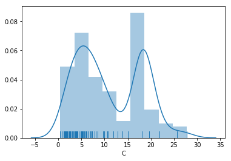

```python
import seaborn as sns
import matplotlib.pyplot as plt
%matplotlib inline
# univariate plots to see individual distribution
sns.distplot(a=boston['C'],rug=True) #kde=true & hist=true by default
```

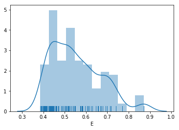

```python
sns.distplot(a=boston['E'],rug=True) #kde=true & hist=true by default
```

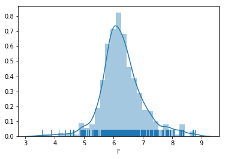

```python
sns.distplot(a=boston['F'],rug=True)
```

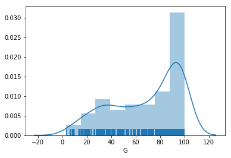

```python
sns.distplot(a=boston['G'],rug=True)
```

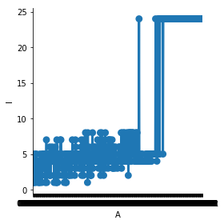

```python
sns.factorplot(x="A",y="I",data=boston)
```

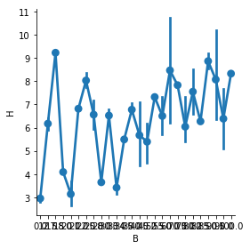

```python
sns.factorplot(x="B",y="H",data=boston)
```

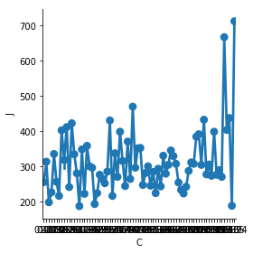

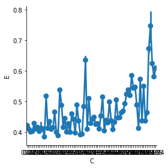

```python
sns.factorplot(x="C",y="J",data=boston)
sns.factorplot(x="C",y="E",data=boston)
```

```
---------------------------------------------------------------------------
AttributeError                            Traceback (most recent call last)
<ipython-input-38-65d43280a123> in <module>()
      1 sns.jointplot(x = "A", y = "I", data = boston, size = 5, kind = "scatter") #scatter is default kind
----> 2 sns.plt.show()

AttributeError: module 'seaborn' has no attribute 'plt'
```

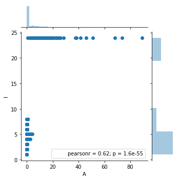

```python
sns.jointplot(x = "A", y = "I", data = boston, size = 5, kind = "scatter") #scatter is default kind
sns.plt.show()
```

```
---------------------------------------------------------------------------
AttributeError                            Traceback (most recent call last)
<ipython-input-41-81d7d491c3c2> in <module>()
      3 sns.jointplot(x = "J", y = "E", data = boston, size = 5, kind = "scatter") #scatter is default kind
      4
----> 5 sns.plt.show()

AttributeError: module 'seaborn' has no attribute 'plt'
```

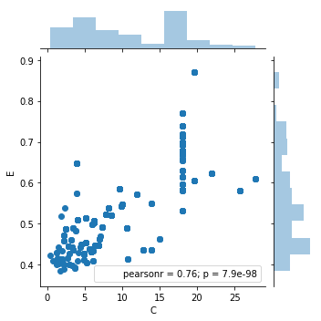

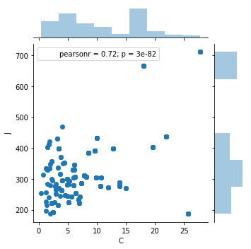

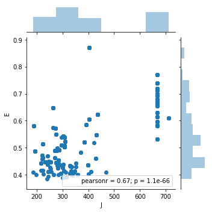

```python
sns.jointplot(x = "C", y = "E", data = boston, size = 5, kind = "scatter") #scatter is default kind
sns.jointplot(x = "C", y = "J", data = boston, size = 5, kind = "scatter") #scatter is default kind
sns.jointplot(x = "J", y = "E", data = boston, size = 5, kind = "scatter") #scatter is default kind

sns.plt.show()
```